# Chap9.10

Mijeong Kim

```r
library(tsibble)
library(tsibbledata)
library(tibble)
library(dplyr)
library(knitr)
library(ggplot2)
library(fpp3)
library(fpp2)
library(seasonal)
library(feasts)
```

## 9.10 ARIMA vs ETS

- 일반적으로 **ARIMA가 지수평활(ETS, exponential smoothing)보다 더 일반적**이라는 오해가 있다.
- **선형 ETS 모델**은 ARIMA의 특수한 경우로 표현 가능하지만,  
  **비선형 ETS 모델**은 ARIMA로 표현 불가능하다.
- 반대로, **일부 ARIMA 모델**도 ETS로 표현할 수 없다.
- **ETS 모델은 모두 비정상성(non-stationary)**을 갖지만,  
  일부 **ARIMA 모델은 정상성(stationary)**을 가진다.

- **추가적 ETS 모델**은 **ARIMA 모델과 등가**가 될 수 있다.
- **ETS 모델 중 계절성 또는 감쇠되지 않은 추세**를 가진 모델은 **두 개의 단위근(unit root)**을 가진다.
- 나머지 ETS 모델은 하나의 단위근을 가지며, 1차 차분이 필요하다.

#### ETS vs ARIMA 모델 등가 관계 (Table 9.4)

| ETS.model | ARIMA.model | Parameters |
| --- | --- | --- |
| ETS(A,N,N) | ARIMA(0,1,1) | $$\theta_1 = \alpha - 1$$ |
| ETS(A,A,N) | ARIMA(0,2,2) | $$\theta_1 = \alpha + \beta - 2$$ , $$\theta_2 = 1 - \alpha$$ |
| ETS(A,Ad,N) | ARIMA(1,1,2) | $$\phi_1 = \phi$$ , $$\theta_1 = \alpha + \phi\beta - 1 - \phi$$ , $$\theta_2 = (1 - \alpha)\phi$$ |
| ETS(A,N,A) | ARIMA(0,1,m)(0,1,0)[m] |  |
| ETS(A,A,A) | ARIMA(0,1,m+1)(0,1,0)[m] |  |
| ETS(A,Ad,A) | ARIMA(1,0,m+1)(0,1,0)[m] |  |

#### AICc의 한계

- **동일 모델 클래스 내**에서는 AICc로 모형 선택 가능
  - ARIMA 후보군 비교 O
  - ETS 후보군 비교 O
- 그러나 **ARIMA와 ETS 간 비교에는 AICc 사용 불가**
  - 이유: **우도(likelihood) 계산 방식이 다르기 때문**

### ARIMA vs ETS 비교 방법: 비계절 자료 예시

- 비계절형 자료에서는 **시계열 교차검증(time series cross-validation)**을 통해 ARIMA와 ETS 모델 성능 비교 가능
- 예시: `global_economy` 데이터셋의 **호주 인구 데이터**
  - Section 8.2에서 소개됨

```r
aus_economy <- global_economy |>
  filter(Code == "AUS") |>
  mutate(Population = Population/1e6)

aus_economy |>
  slice(-n()) |>
  stretch_tsibble(.init = 10) |>
  model(
    ETS(Population),
    ARIMA(Population)
  ) |>
  forecast(h = 1) |>
  accuracy(aus_economy) |>
  select(.model, RMSE:MAPE)
```

```
## # A tibble: 2 × 5
##   .model              RMSE    MAE   MPE  MAPE
##   <chr>              <dbl>  <dbl> <dbl> <dbl>
## 1 ARIMA(Population) 0.194  0.0789 0.277 0.509
## 2 ETS(Population)   0.0774 0.0543 0.112 0.327
```

이 경우, ETS 모델이 교차검증 성능 지표에서 더 높은 정확도를 나타냈다. 아래에서는 ETS 모델을 이용하여 향후 5년간의 예측을 생성하고 시각화한다.

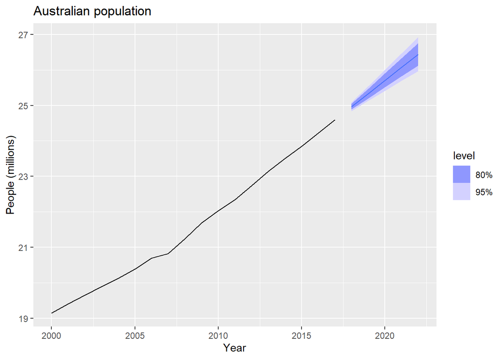

```r
aus_economy |>
  model(ETS(Population)) |>
  forecast(h = "5 years") |>
  autoplot(aus_economy |> filter(Year >= 2000)) +
  labs(title = "Australian population",
       y = "People (millions)")
```

Figure 9.28: Forecasts from an ETS model fitted to the Australian population.

이번에는 계절형 시계열 데이터에 대해 ARIMA()와 ETS() 모델을 비교한다. 사용 데이터는 aus_production의 분기별 시멘트 생산량이다.

시계열 길이가 충분히 길기 때문에, 시계열 교차검증 대신 훈련 세트와 테스트 세트로 분리하여 비교할 수 있으며, 이 방식은 속도가 더 빠르다는 장점이 있다.

- Training set : 1988년 초 ~ 2007년 말
- 이후 ARIMA()와 ETS() 함수를 사용해 각 모델을 선택한다.

```r
cement <- aus_production |>
  select(Cement) |>
  filter_index("1988 Q1" ~ .)
train <- cement |> filter_index(. ~ "2007 Q4")
```

아래 출력은 ARIMA() 함수로 선택 및 추정된 모델을 보여준다. 해당 ARIMA 모델은 데이터의 모든 동적 특성을 잘 포착하고 있으며, 잔차가 백색잡음처럼 보이는 점에서 모델의 적합성이 높음을 알 수 있다.

```r
fit_arima <- train |> model(ARIMA(Cement))
report(fit_arima)
```

```
## Series: Cement
## Model: ARIMA(1,0,1)(2,1,1)[4] w/ drift
##
## Coefficients:
##          ar1      ma1   sar1     sar2     sma1  constant
##       0.8886  -0.2366  0.081  -0.2345  -0.8979    5.3884
## s.e.  0.0842   0.1334  0.157   0.1392   0.1780    1.4844
##
## sigma^2 estimated as 11456:  log likelihood=-463.52
## AIC=941.03   AICc=942.68   BIC=957.35
```

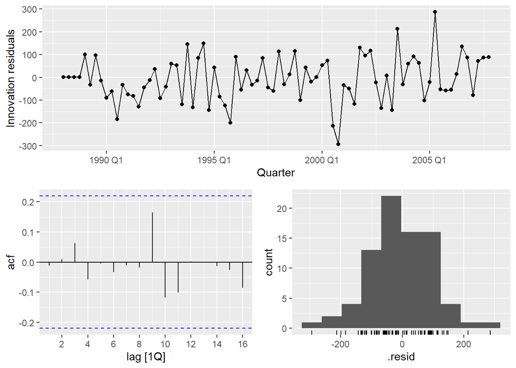

```r
fit_arima |> gg_tsresiduals(lag_max = 16)
```

Figure 9.29: Residual diagnostic plots for the ARIMA model fitted to the quarterly cement production training data.

```r
augment(fit_arima) |>
  features(.innov, ljung_box, lag = 16, dof = 5)
```

```
## # A tibble: 1 × 3
##   .model        lb_stat lb_pvalue
##   <chr>           <dbl>     <dbl>
## 1 ARIMA(Cement)    6.37     0.847
```

아래 출력은 ETS() 함수로 선택 및 추정된 모델을 보여준다. 이 모델 또한 데이터의 동적 특성을 잘 포착하고 있으며, 잔차가 백색잡음처럼 보여 적합한 모델임을 확인할 수 있다.

```r
fit_ets <- train |> model(ETS(Cement))
report(fit_ets)
```

```
## Series: Cement
## Model: ETS(M,N,M)
##   Smoothing parameters:
##     alpha = 0.7533714
##     gamma = 0.0001000093
##
##   Initial states:
##      l[0]     s[0]    s[-1]    s[-2]     s[-3]
##  1694.712 1.031179 1.045209 1.011424 0.9121874
##
##   sigma^2:  0.0034
##
##      AIC     AICc      BIC
## 1104.095 1105.650 1120.769
```

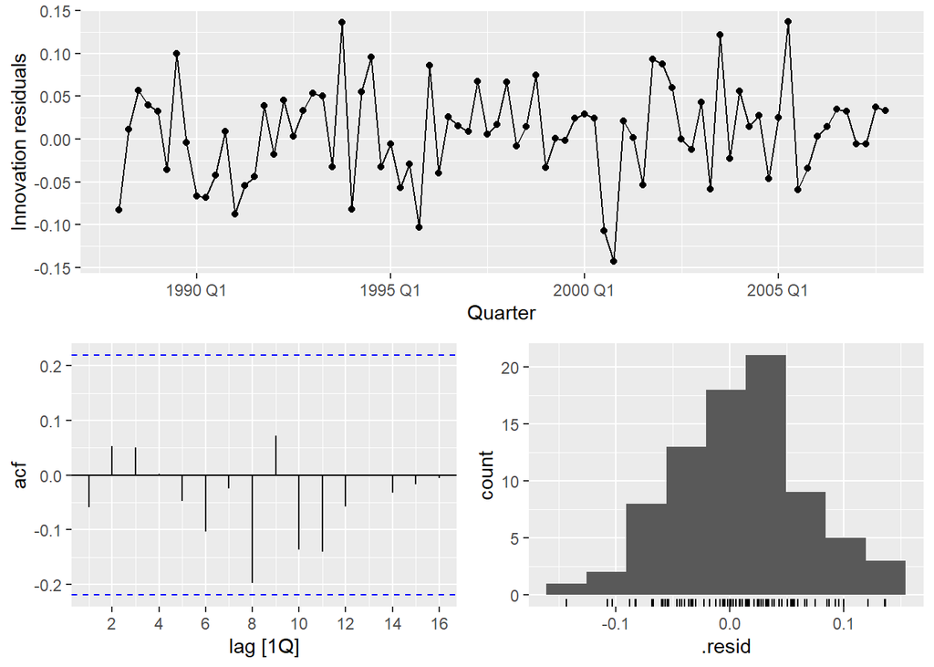

```r
fit_ets |>
  gg_tsresiduals(lag_max = 16)
```

Figure 9.30: Residual diagnostic plots for the ETS model fitted to the quarterly cement production training data.

```r
augment(fit_ets) |>
  features(.innov, ljung_box, lag = 16)
```

```
## # A tibble: 1 × 3
##   .model      lb_stat lb_pvalue
##   <chr>         <dbl>     <dbl>
## 1 ETS(Cement)    10.0     0.865
```

아래 출력은 테스트 세트에서 ARIMA와 ETS 두 모델의 예측 성능을 평가한 결과이다. 이 경우, ARIMA 모델이 RMSE, MAPE, MASE 지표에서 약간 더 높은 정확도를 보이며, 두 모델 중 더 우수한 성능을 가진 것으로 판단된다.

```r
# Generate forecasts and compare accuracy over the test set
bind_rows(
    fit_arima |> accuracy(),
    fit_ets |> accuracy(),
    fit_arima |> forecast(h = 10) |> accuracy(cement),
    fit_ets |> forecast(h = 10) |> accuracy(cement)
  ) |>
  select(-ME, -MPE, -ACF1)
```

```
## # A tibble: 4 × 7
##   .model        .type     RMSE   MAE  MAPE  MASE RMSSE
##   <chr>         <chr>    <dbl> <dbl> <dbl> <dbl> <dbl>
## 1 ARIMA(Cement) Training  100.  79.9  4.37 0.546 0.582
## 2 ETS(Cement)   Training  103.  80.0  4.41 0.547 0.596
## 3 ARIMA(Cement) Test      216. 186.   8.68 1.27  1.26
## 4 ETS(Cement)   Test      222. 191.   8.85 1.30  1.29
```

아래에서는 ARIMA 모델을 이용해 향후 3년간의 예측을 생성하고 시각화한다.

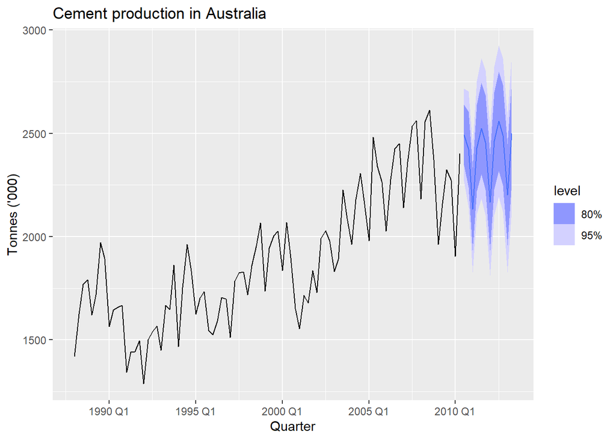

```r
cement |>
  model(ARIMA(Cement)) |>
  forecast(h="3 years") |>
  autoplot(cement) +
  labs(title = "Cement production in Australia",
       y = "Tonnes ('000)")
```

Figure 9.31: Forecasts from an ARIMA model fitted to all of the available quarterly cement production data since 1988.